# Optimizers

The ultimate goal of an ML model is to reach the minimum of the loss function. This is where an **optimizer** comes into play, defining how to tweak the parameters to get closer to the minima.

It is the way modern machine learning models **learn**, and is evidently very important.

In mathematical terms, to fit a model, we need a training set {xi, yi} of input/output pairs. We seek parameters ϕ for the model f[xi, ϕ] that map the inputs xi to the outputs yi as closely as possible. To this end, we define a loss function L[ϕ] that returns a single number that quantifies the mismatch in this mapping. The goal of an optimization algorithm is to find parameters ϕˆ that minimize the loss:

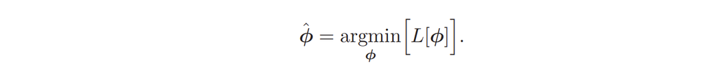

There are many families of optimization algorithms, but the standard methods for training neural networks are iterative. These algorithms initialize the parameters heuristically and then adjust them repeatedly in such a way that the loss decreases.

# 1. Gradient Descent

Gradient Descent is the father of iterative optimizers, and most others mentioned after this are based on Gradient Descent.

## 1.1 Intuition

Imagine you are in a valley, and want to go down, how will you do that? You will take small but steady steps downhill to reach the bottom. This is what this optimizer tries to simulate.

Basically, to decrease the cost from the cost function, it computes partial derivatives to find the optimal direction that leads downwards, iteratively. This will eventually find a local minimum.

## 1.2 Mathematics

In gradient descent, we calculate the gradients by taking the average of the gradients of each datapoint. This ensures equal representation of each datapoint, avoiding bias towards any single datapoint.

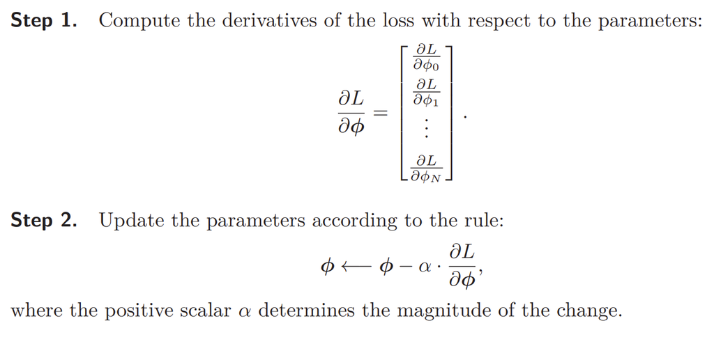

Alpha is most commonly called the **learning rate** of the model. This Hyperparameter must be chosen [carefully](https://www.geeksforgeeks.org/machine-learning/impact-of-learning-rate-on-a-model/).

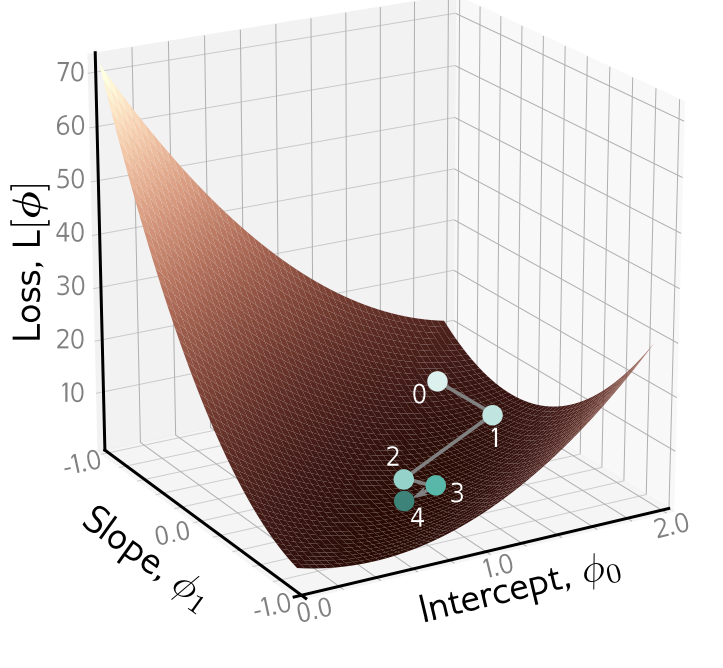

This picture is of the cost function of a Linear regression model being navigated by Gradient Descent.

Loss function showing iterations of gradient descent. We start at point 0 and move in the steepest downhill direction until we can improve no further to arrive at point 1. We then repeat this procedure. We measure the gradient at point 1 and move downhill to point 2, and so on.

## 1.3 Problems with Gradient Descent

Even though this is the parent optimizer, it still has some problems, which have been combated with future optimizers. Some of the problems are mentioned below.

### 1.3.1 Slow Convergence

The optimizer often gets stuck in plateaus and other places where gradients are close to zero, and also, compared to other optimizers, it converges very slowly in general. In cases of narrow minima, specifically, Gradient Descent is very slow as well.

### 1.3.2 Getting Stuck in Local Minima or Saddle Points

If you think about it for some time, you will conclude that Gradient Descent doesn't stop the model from converging at local minima, which aren't the global minima. This is undesirable because you are stuck with a suboptimal model.

Models like Linear Regression famously have only convex cost functions, hence only one minimum, leading to an optimal solution through Gradient Descent regardless of the initialization of parameters. But for Deep Learning models like Shallow and Deep Neural Networks, the cost function is non-convex, leading to many local minima and saddle points.

This problem can be rectified by training the model on different initializations of the parameters, and checking which has the least loss, but that also is unrealistic given the sheer size of modern deep learning models.

### 1.3.3 Inefficient with Large Datasets

Full-batch gradient descent must compute gradients over the **entire dataset** each step. For larger datasets containing thousands, if not millions of datapoints, Gradient Descent is very slow and memory-intensive.

# 2. Stochastic and Mini-Batch Gradient Descent

## 2.1 Intuition

Gradient Descent is not viable for Huge Datasets, which are common with Deep learning models, containing a huge amount of parameters. These optimizers try to solve this problem.

Instead of taking an average of the whole dataset to find gradients to descend upon, we instead take averages of randomized subsets of the dataset. If these subsets consist of only one datapoint, the optimizer is called **Stochastic Gradient Descent**, and if the subsets have more than 1 datapoint, it is called **Mini-Batch Gradient Descent**.

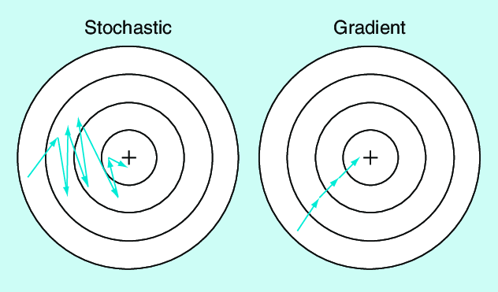

Other than the number of gradients taken for each iteration of training, there is no other difference between normal Gradient Descent and Stochastic/Mini-Batch Gradient Descent.

An **epoch** is one complete pass through the entire training dataset by the learning algorithm. So basically, each epoch consists of shuffling the dataset, training the model on each subset of the dataset until the whole dataset is covered.

## 2.2 Advantages and Disadvantages

### 2.2.1 Advantages

We already talked about one of the advantages over normal Gradient Descent. It decreases the computation needed per iteration, which evidently masks some information about the dataset per iteration, but it averages out due to the large number of iterations, as expected due to the [Law of Large Numbers](https://en.wikipedia.org/wiki/Law_of_large_numbers). And also, less memory usage is a great advantage.

Another advantage is the possibility of escaping saddle points and local minima, due to the stochastic nature of the optimizer. In case of saddle points, the model has the ability to escape them fast, as the subset does not represent the whole dataset. This is due to the fact that even in the case of a saddle point, there is minimal chance of the subset also averaging out to zero gradient. Similarly, for local minima, the seemingly random steps taken by SGD/MBGD help the model escape those regions.

It is also believed that the inherent randomness in **SGD/MBGD acts like a regularizer**, which can lead to better generalization and lower overfitting.

### 2.2.2 DIsadvantage

While SDG and MBDG find “good enough” solutions much faster than vanilla GD, due to the inherent noisy updates of the parameters, they may not converge well after reaching close to the minimum without using techniques like a [learning rate scheduler](https://d2l.ai/chapter_optimization/lr-scheduler.html). Later optimizers will try to address this issue.

## 2.3 Difference between SGD and MBGD

There are some obvious differences between SGD and MBGD, one is the **gradient estimation**. For SGD, it's very noisy, and for MBGD, it's less noisy and more stable in comparison. One may argue that the noisier the estimate, the more the ability to escape local minima/saddle points. But think of it this way, without a good gradient estimate, the convergence will be painfully slow or even impossible. For most tasks, MBGD seems to be the best tradeoff in terms of gradient estimation and also noisiness to escape plateaus and minima.

Another difference is the use of the capabilities of GPUs to do **parallel computing**. Since SGD uses only one data point per update, there’s nothing to compute in parallel. This renders GPUs largely ineffective, failing to take advantage of parallelism in a field like machine learning, where time efficiency is paramount.

MBGD introduces another hyperparameter to train a model, batch size. This may be taken as a disadvantage of the optimizer, but the advantages far outweigh this problem.

Unsurprisingly, the concept of Mini-Batch Gradient Descent is used in the future, in more advanced optimizers, more specifically, the use of only a subset of datapoints per iteration.

# 3. Momentum

## 3.1 Intuition

Let us start by taking a real-life physics problem, the classical example used to explain this optimizer. Let's say we roll a ball from a high hill. The ball will try to go down the hill and finally rest on the lowest point it can find. If we imagine the graph of the cost function as a landscape, the ball being the point where we stand on that landscape/graph, this is what an optimizer wants to do. Now, let's say we put a small rock in the path of the ball. What will it do? The ball will not be stopped by the rock; move past it to find a lower point. Even if it finds flat land, it will not just instantly stop; it will still move towards its target. This property is missing from the vanilla Gradient Descent or even SGD and MBGD.

Now, what is missing in these optimizers so not able from behaving like the ball here. Simply, this is made possible by a property of the ball, called **momentum**.

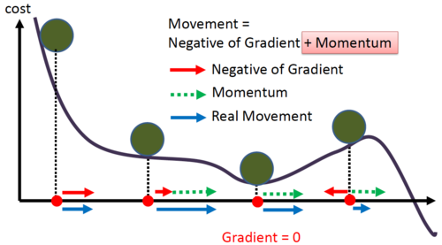

## 3.2 Mathematics

To roughly simulate this property, we add a momentum term. We update the parameters with a weighted combination of the **gradient** computed from the current batch and the **direction moved in the previous step**.

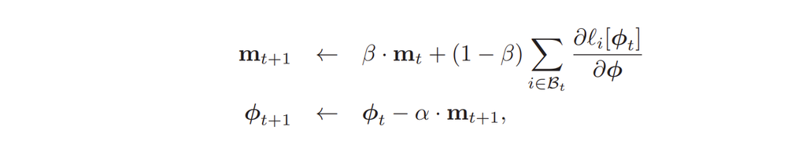

where mt is the momentum (which drives the update at iteration t), β ∈ [0, 1) controls the degree to which the gradient is smoothed over time, and alpha is the learning rate.

The recursive formulation of the momentum calculation means that the gradient step is an infinite weighted sum of all the previous gradients, where the weights get smaller as we move back in time. The effective learning rate increases if all these gradients are aligned over multiple iterations, but decreases if the gradient direction repeatedly changes as the terms in the sum cancel out. The overall effect is a smoother trajectory and reduced oscillatory behavior in valleys.

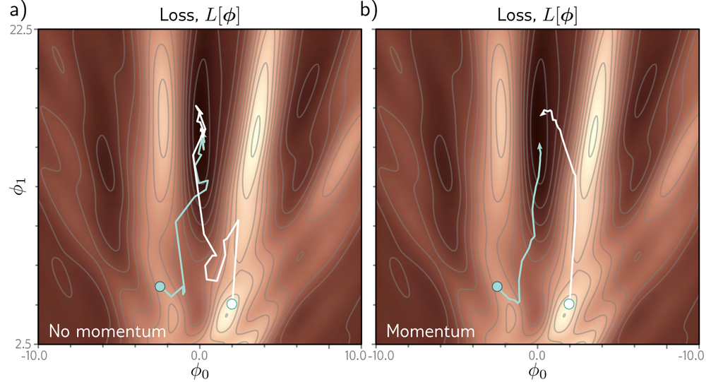

## 3.3 Advantages and Disadvantages

### 3.3.1 Advantages

This optimizer helps reduce convergence time. It builds up speed in directions with consistent gradients, helping reach minima faster. Especially effective in ravines or valleys. Intuitively, we can also conclude that it majorly helps escape saddle points and minima. Smooths out the "zig-zag" behavior in directions with high curvature (common in deep networks). While it may not be clear why this is helpful, think of it as a damper of the oscillations caused by the noisy updates due to MBGD/SGD. Importantly, it only dampens the noisiness, but does not eliminate it. You may even argue that noise was one of the advantages of these previous optimizers. But in practice, momentum performs much better than SGD/MBGD with no momentum.

### 3.3.2 Disadvantages

One of the problems with this optimizer, as the astute may have already partially realised, is overshooting the minimum. Jusy like a ball falling from a mountain, this will also oscillate before finally reaching the minimum, which is amplified if beta is set too high. This can be combated with methods like Learning Rate Scheduling.

It also introduces another hyperparameter, beta.

# 4. Nesterov Accelerated Gradient

## 4.1 Intuition

Momentum moves based on the current gradient at. You can say that it is "blindly" accelerating, hoping it is still heading toward the minimum. This new optimizer, instead looks a little ahead and calculates the move based on that. So it moves based on momentum and then calculates the gradients.

The momentum term can be considered a coarse prediction of where the SGD algorithm will move next. Nesterov accelerated momentum computes the gradients at this predicted point rather than at the current point:

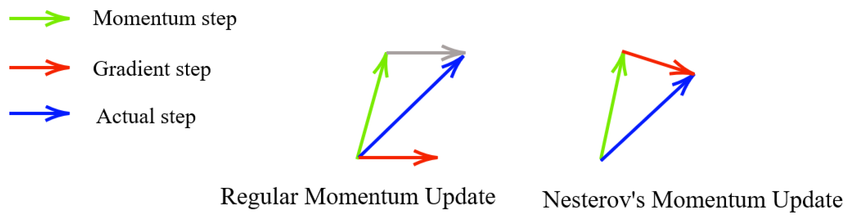

## 4.2 Mathematics

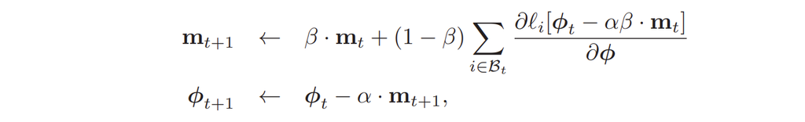

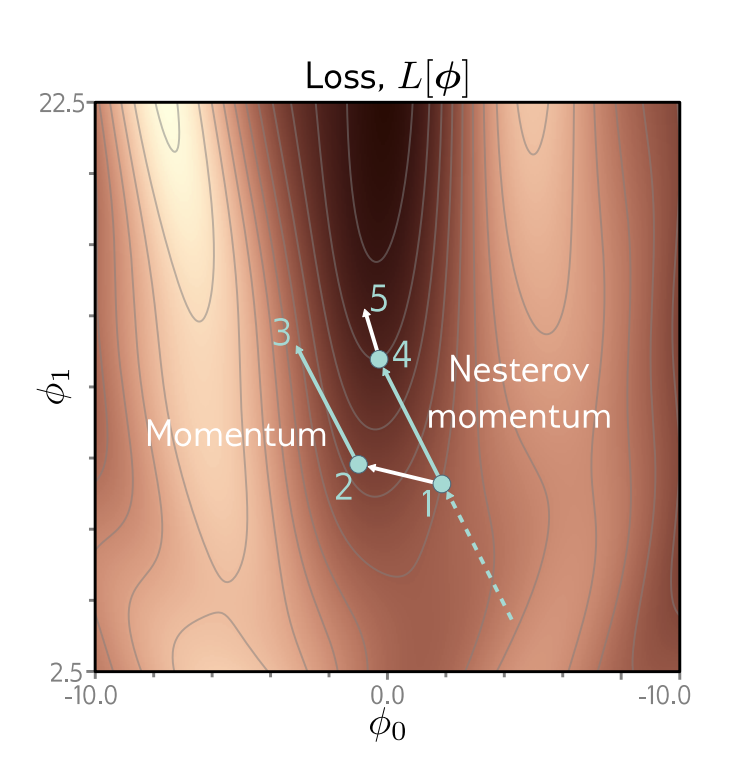

Nesterov accelerated momentum. The solution has traveled along the dashed line to arrive at point 1. A traditional momentum update measures the gradient at point 1, moves some distance in this direction to point 2, and then adds the momentum term from the previous iteration (i.e., in the same direction as the dashed line), arriving at point 3. The Nesterov momentum update first applies the momentum term (moving from point 1 to point 4) and then measures the gradient and applies an update to arrive at point 5.

## 4.3 Advantages and Disadvantages

### 4.3.1 Advantages

NAG is a clear improvement over the vanilla momentum optimizer, as it converges a little faster, handles irregular terrains better, and reduces overshooting. It also performs better in practice. You can argue it is an overall improvement of the momentum optimizer.

### 4.3.2 Disadvantages

While the advantages it provides are clear, they may be only slight improvements. Sometimes its hard to know if the additional cost of compute compared to momentum is worth the improvement.

# 5. AdaGrad

## 5.1 Intuition

This optimizer starts a series of new algorithms called **Adaptive Optimizers**. SGD (and momentum) use the same learning rate for all parameters, regardless of how frequently or infrequently that parameter is updated or how sensitive it is. But not all parameters should learn equally fast. Frequently updated parameters should learn more slowly over time, while rarely updated parameters should be allowed to learn faster.

AdaGrad’s main intuition is that - the more a parameter has been updated in the past, the less it should be updated now.

## 5.2 Mathematics

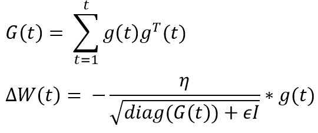

Here, epsilon is a small positive constant to avoid dividing by 0, and g(t) is the gradient at time t.

The learning rate is divided by the square root of this accumulated sum. In simpler terms, we just divide the learning rate by the RMS of previous gradients. This means that parameters that have received large or frequent updates will have their learning rates reduced over time, while those that are updated less frequently will retain relatively larger learning rates. As a result, AdaGrad naturally slows down learning for well-trained parameters and allows under-trained ones to catch up.

## 5.3 Advantages and Disadvantages

### 5.3.1 Advantages

AdaGrad adapts the learning rate independently for each parameter, improving efficiency in models with sparse or uneven data.

### 5.3.2 Disadvantages

There is a major problem with Adagrad. With huge datasets to train the models on, you can imagine intuitively that at some point, the learning rate for some parameters will decrease to a point where the model stops learning. This, expectedly, is a problem faced in practice too.

In short, the learning rate decay is too strong and aggressive.

This optimizer was not working as the effective learning rate was highly correlated with the iterations of training previously performed by the model. Even if a parameter was learning slowly, with enough iterations, the learning rate would turn out to be painfully small.

# 6. Root Mean Square Propagation

## 6.1 Intuition

PMSProp tries to improve the major shortcomings of AdaGrad. Instead of summing all past squared gradients, RMSProp uses a moving average, giving more weight to recent gradients and forgetting old ones. The influence of the old gradients slowly but surely decays away. This decreases the dependency of the effective learning rate on the number of iterations performed by the model, eliminating a problem faced by AdaGrad.

## 6.2 Mathematics

Instead of taking the average of the squares of gradients, we basically take a weighted sum such that the contribution of the older gradients decreases per iteration to combat the problems faced by AdaGrad.

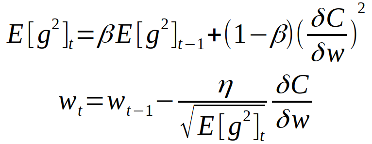

## 6.3 Advantages and Disadvantages

RMSProp improves on AdaGrad by using a moving average of squared gradients instead of a total sum, fixing the issue of learning rates decaying too aggressively.

It's better suited for long training, non-stationary data, and deep models, but it introduces a new hyperparameter and loses some of AdaGrad’s simplicity.

# 7. Adam

## 7.1 Intuition

Adam attempts to combine two optimizers, RMSProp and Momentum. Classical Adam tracks both the previous gradients and the momentum of the previous steps.

## 7.2 Mathematics

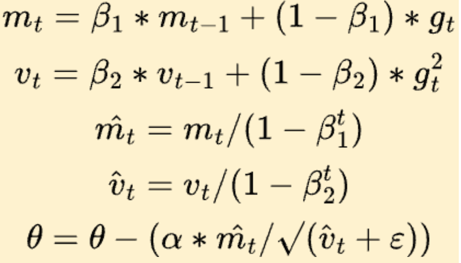

m and v track the momentum and gradients, respectively. Because m and v start at 0, they’re biased toward zero early on. So we fix that with the next 2 equations. These corrected values are more accurate in early iterations. The variable t simply refers to the current time step or iteration number.

As per the [paper](https://arxiv.org/pdf/1412.6980) that proposed Adam, good default settings for the tested machine learning problems are α = 0.001, β1 = 0.9, β2 = 0.999, and epsilon = 10^-8.

Adam is the **most popular and versatile** optimizer in deep learning today, offering a strong balance of speed, adaptivity, and stability. Obviously, other older optimizers may outperform it in very specific tasks, but overall, most people nowadays start and stick with Adam while creating a machine learning model.

a) This loss function changes quickly in the vertical direction but slowly in the horizontal direction. If we run full-batch gradient descent with a learning rate that makes good progress in the vertical direction, then the algorithm takes a long time to reach the final horizontal position. b) If the learning rate is chosen so that the algorithm makes good progress in the horizontal direction, it overshoots in the vertical direction and becomes unstable. c) A straightforward approach is to move a fixed distance along each axis at each step so that we move downhill in both directions. This is accomplished by normalizing the gradient magnitude and retaining only the sign. However, this does not usually converge to the exact minimum but instead oscillates back and forth around it (here between the last two points). d) The Adam algorithm uses momentum in both the estimated gradient and the normalization term, which creates a smoother path.

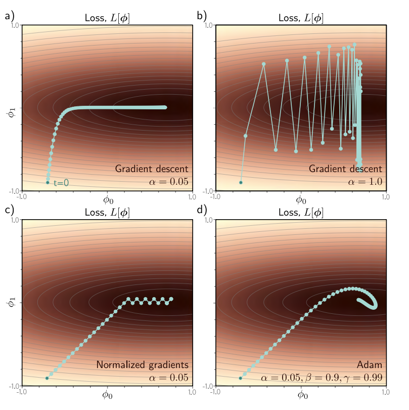

# 8. Optimizers After Adam

After the emergence of Adam and also in the paper that first mentions it, many other Adam versions were created/ mentioned. Two that come to mind are AdamW and Nadam.

Other optimizers like AMSGrad, Lion, Adan, and Lookahead have also been proposed. While they are new and lack the amount of research that has been put into Adam, some seem promising and may provide faster convergence based on the task, compared to Adam.

I will not elaborate on these optimizers further, but do check their basic intuition at least if you are interested.